# Reproducible Research

Pablo Mosteiro

p.mosteiro@uu.nl

Methodology & Statistics @ UU

Hanne Oberman

h.i.oberman@uu.nl

Methodology & Statistics @ UU

5 Nov 2025

# Overview

## Today’s class

- Reproducibility
- Research compendiums

[figure not shown]

## Why bother?

We would like our results to be as fully reproducible as possible:

A. **Reproducibility is one of the pillars of science**

- It is the standard by which to judge scientific claims
- It helps the cumulative growth of knowledge - no duplication of effort

B. **Reproducibility may greatly benefit you**

- You’ll develop better work habits
- Better teamwork - especially with new team members
- Changing or amending your work is much easier
- Higher research impact - more likely to be picked up and cited

## By the end of this class…

- … you will have heard *what* reproducible research is and *why* it is important
- … you have *applied* this knowledge by *critiquing* the reproducibility of case study
- … you will be able to *produce* a reproducible research archive from scratch

# Reproducibility

## Crisis?

[figure not shown]

[Baker (2016)](https://www.nature.com/articles/533452a)

## Definition

> A result is **reproducible** when the *same* analysis steps performed on the *same* dataset consistently produces the *same* answer.

[The Turing way](https://the-turing-way.netlify.app/reproducible-research/overview/overview-definitions#rr-overview-definitions)

## Definition

> Research results are **replicable** if there is sufficient information available for independent researchers to make the same findings using the same procedures.

[King (1995)](https://gking.harvard.edu/files/gking/files/replication.pdf)

## True or false?

In computational sciences - such as ours - simply having the data and code means that the results are not only replicable, but fully reproducible.

## Reproducibility of `R` scripts

Reproducible research is not the norm:

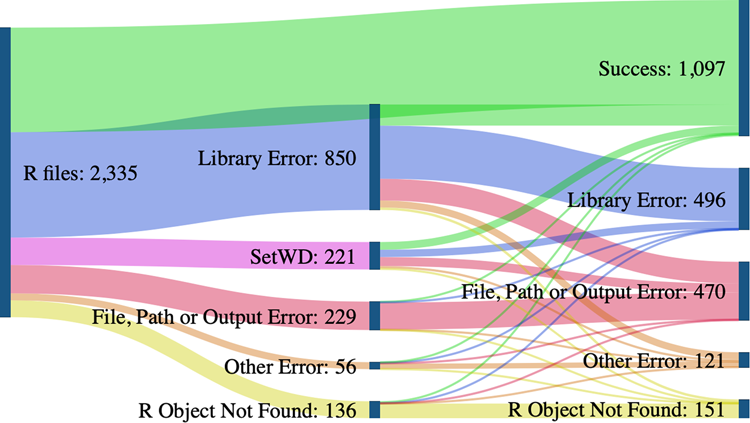

[Trisovic, Lau, Pasquier, et al., 2022](https://doi.org/10.1038/s41597-022-01143-6)

## Reproducibility spectrum

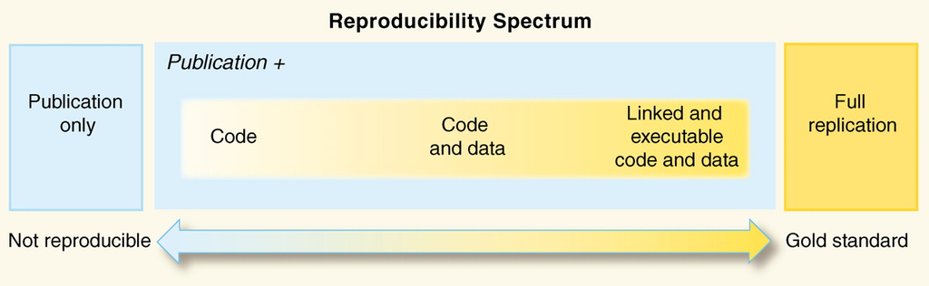

[Peng (2011)](https://doi.org/10.1126/science.1213847)

## Case study

[figure not shown]

[Boulesteix, Groenwold, Abrahamowicz, et al. (2020)](https://doi.org/10.1136/bmjopen-2020-039921)

## Case study

> Our study is completely reproducible using the R code provided in [online supplemental file 1](https://bmjopen.bmj.com/highwire/filestream/195583/field_highwire_adjunct_files/0/bmjopen-2020-039921supp001_data_supplement.pdf), which uses freely available data.

```
# ====================================================================
# R CODE
# small scale simulation study to investigate impact of measurement error
# measurement error on (continuous) exposure and/or (continuous) confounding variable
# ====================================================================
# ====================================================================
# libraries:
library(Hmisc)
library(mice)
library(tidyverse)
```

[Boulesteix, Groenwold, Abrahamowicz, et al. (2020)](https://doi.org/10.1136/bmjopen-2020-039921)

## Making research reproducible

- reproducible documents
- FAIR & TADA
- research compendiums

[figure not shown]

## FAIR

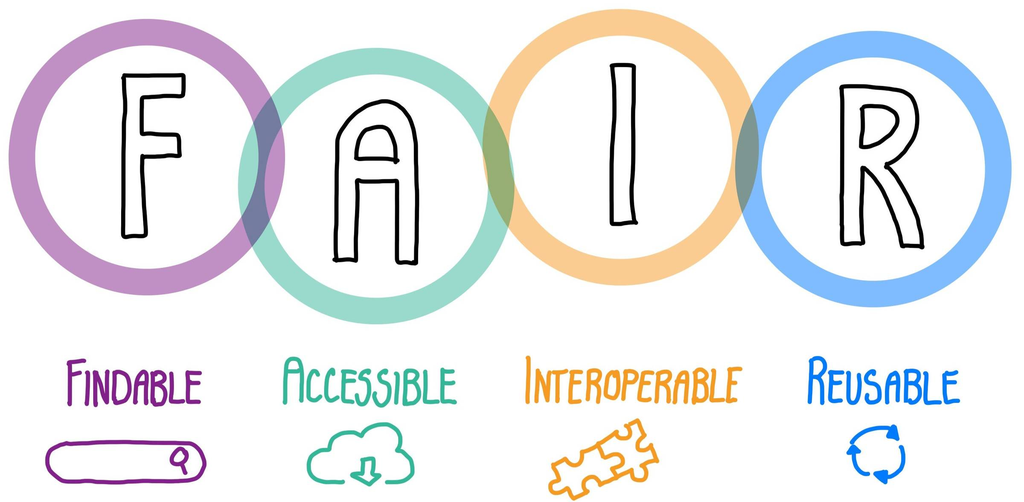

## TADA

[Ivimey-Cook et al. (2025)](https://doi.org/10.32942/X2D93K)

[figure not shown]

# Research Compendiums

## Research compendium

[figure not shown]

## Definition

> A research compendium is a collection of all digital parts of a research project including data, code, texts…

> The collection is created in such a way that reproducing all results is straightforward<sup>1</sup>

> The compendium serves as a means for distributing, managing, and updating the collection<sup>2</sup>
[^1]: [The Turing Way](https://the-turing-way.netlify.app/reproducible-research/compendia)
[^2]: [Gentleman & Temple Lang (2007)](https://doi.org/10.1198/106186007X178663)

## Basic compendium

A basic research compendium is just a folder…

```
compendium/
├── data
│   └── my_data.csv
├── analysis
│   └── my_script.R
├── requirements.txt
└── README.md
```

## (Not so) basic compendium

… but it can become extensive…

```
├── paper/
│   ├── paper.qmd
│   └── references.bib
├── figures/
├── data/
│   ├── raw_data/
│   └── clean_data/
└── templates
    └── journal_template.csl
```

## (Not so) basic compendium

…or even executable!

```
├── _targets.R
├── R/
│   ├── functions_data.R
│   ├── functions_analysis.R
│   ├── functions_visualization.R
└── data/
    └── input_data.csv
```

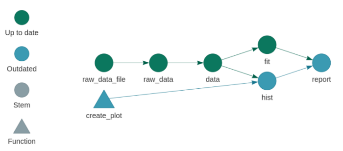

e.g. with the `targets` package or `Make` files

## Gold standard?

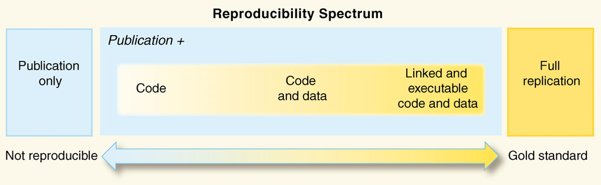

[Peng (2011)](https://doi.org/10.1126/science.1213847)

## Random number generation

```r
set.seed(1L)
sample(1:10)
```

```
 [1]  9  4  7  1  2  5  3 10  6  8
```

```r
sample(1:10)
```

```
 [1]  3  1  5  8  2  6 10  9  4  7
```

```r
set.seed(1L)
sample(1:10)
```

```
 [1]  9  4  7  1  2  5  3 10  6  8
```

[Navarro (2025)](https://blog.djnavarro.net/posts/2025-05-18_multivariate-normal-sampling-floating-point)

## Reproducible environment or containerized

[figure not shown]

e.g. with the `renv` package or a `Docker` container

## Guidelines

- Completeness
- Organization
- Economy
- Transparency
- Documentation
- Access
- Provenance
- Metadata
- Automation
- Review

[figure not shown]

## In practice

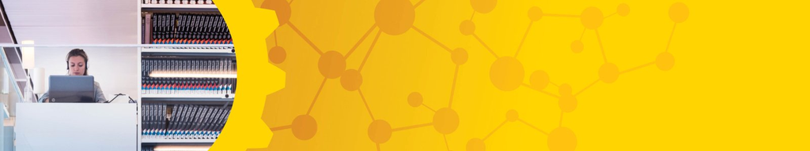

Research Data Management Support workshop:

[**Writing Reproducible Manuscripts in R and Python**](https://utrechtuniversity.github.io/workshop-reproducible-manuscripts/introduction.html)

## Steps

- Think about a good folder structure
  - Split up ‘read-only’, ‘human-generated’, and ‘project-generated’ files
- Create folder structure (main directory and sub directories)
  - Add a landing page in the form of a README document
  - Make the compendium executable (to automatically generate the results; optional)
  - Make the compendium into a git repository (optional)
- Add all files needed for reproducing the results of the project
  - Avoid ‘hard coded’ parameters or human intervention in the execution
- Make the compendium as clean and easy to use as possible
  - Include a citation file and a LICENSE file with info on how it can be used
- Publish your compendium
  - E.g. on Zenodo (optional, more on this in the last course week)

Adapted from [The Turing Way](https://the-turing-way.netlify.app/reproducible-research/compendia#checklist)

## Bonus: Preregister your simulation study

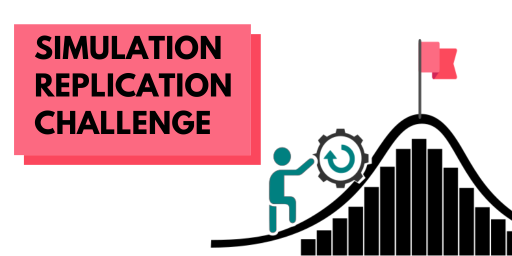

[Siepe et al. (2024)](https://doi.org/10.1037/met0000695)

[RepliSims](https://replisims.org)

# Wrap-up

## ‘Reproducible’ research

[Boulesteix, Groenwold, Abrahamowicz, et al. (2020)](https://doi.org/10.1136/bmjopen-2020-039921) with the [`pdf` supplement](https://bmjopen.bmj.com/highwire/filestream/195583/field_highwire_adjunct_files/0/bmjopen-2020-039921supp001_data_supplement.pdf)

[figure not shown]

## Reproducible but not replicable

```r
set.seed(1)
run_simulation()
set.seed(2)
run_simulation()
set.seed(3)
```

## Take aways

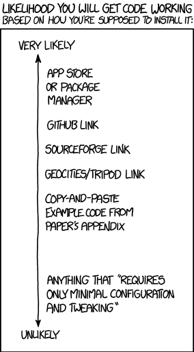

- reproducibility
- research compendiums
- building a compendium

## Next meeting

[figure not shown]

## References and further reading

Baker, M. (2016). 1,500 scientists lift the lid on reproducibility. https://www.nature.com/articles/533452a

Boulesteix, A.-L., Groenwold, R. H., Abrahamowicz, M., Binder, H., Briel, M., Hornung, R., Morris, T. P., Rahnenführer, J., & Sauerbrei, W. (2020). Introduction to statistical simulations in health research. BMJ Open, 10(12), e039921. https://doi.org/10.1136/bmjopen-2020-039921

Bryan, J., & TAs, T. S. 545. (n.d.-a). Chapter 33 Why and how we automate data analyses + examples | STAT 545. Retrieved October 30, 2023, from https://stat545.com/

Checklist. (n.d.). Retrieved October 31, 2023, from https://guide.esciencecenter.nl/#/best_practices/checklist

Checklist for a Software Management Plan. (n.d.). https://doi.org/10.5281/zenodo.2159713

Comment on Oberman & Vink: Should we fix or simulate the complete data in simulation studies evaluating missing data methods? - Morris—Biometrical Journal—Wiley Online Library. (n.d.). Retrieved October 30, 2023, from https://onlinelibrary.wiley.com/doi/full/10.1002/bimj.202300085

Drost, N., Spaaks, J. H., Andela, B., Veen, L., Zwaan, J. M., Verhoeven, S., Bos, P., Kuzak, M., Werkhoven, B., Attema, J., Hidding, J., Hees, V., Martinez-Ortiz, C., Spreeuw, H., Borgdorff, J., Leinweber, K., Diblen, F., Oord, G., Goncalves, R., … Bakker, T. (2020). Netherlands eScience Center—Software Development Guide (v0.9.1). Zenodo. https://doi.org/10.5281/ZENODO.4020564

## References and further reading

Gentleman, R., & Temple Lang, D. (2007). Statistical Analyses and Reproducible Research. Journal of Computational and Graphical Statistics, 16(1), 1–23. https://doi.org/10.1198/106186007X178663

Ivimey-Cook, E. R., Culina, A., Dimri, S., Grainger, M., Kar, F., Lagisz, M., Moran, N. P., Nakagawa, S., Roche, D. G., Sanchez-Tojar, A., Windecker, S. M., & Pick, J. L. (2025). TADA! Simple guidelines to improve code sharing. https://ecoevorxiv.org/repository/view/9806/

Jiménez, R. C., Kuzak, M., Alhamdoosh, M., Barker, M., Batut, B., Borg, M., Capella-Gutierrez, S., Hong, N. C., Cook, M., Corpas, M., Flannery, M., Garcia, L., Gelpí, J. L., Gladman, S., Goble, C., Ferreiro, M. G., Gonzalez-Beltran, A., Griffin, P. C., Grüning, B., … Crouch, S. (2017). Four simple recommendations to encourage best practices in research software (6:876). F1000Research. https://doi.org/10.12688/f1000research.11407.1

Knuth, D. E. (1984). Literate Programming. The Computer Journal, 27(2), 97–111. https://doi.org/10.1093/comjnl/27.2.97

Marwick, B., Boettiger, C., & Mullen, L. (2018). Packaging Data Analytical Work Reproducibly Using R (and Friends). The American Statistician, 72(1), 80–88. https://doi.org/10.1080/00031305.2017.1375986

Morris, T. P., White, I. R., & Crowther, M. J. (2019). Using simulation studies to evaluate statistical methods. Statistics in Medicine, 38(11), 2074–2102. https://doi.org/10.1002/sim.8086

Navarro, D. (2025, May 18). When good pseudorandom numbers go bad. Notes from a Data Witch. https://blog.djnavarro.net/posts/2025-05-18_multivariate-normal-sampling-floating-point/

NHANES Questionnaires, Datasets, and Related Documentation. (n.d.). Retrieved October 30, 2023, from https://wwwn.cdc.gov/nchs/nhanes/continuousnhanes/default.aspx?Begi-nYear=2015

## References and further reading

Nüst, D., Ostermann, F., Sileryte, R., Hofer, B., Granell, C., Teperek, M., Graser, A., Broman, K., Hettne, K., & Clare, C. (2019). AGILE Reproducible Paper Guidelines. https://doi.org/10.17605/OSF.IO/CB7Z8

Peng, R. D. (2011). Reproducible Research in Computational Science. Science, 334(6060), 1226–1227. https://doi.org/10.1126/science.1213847

Reliability and reproducibility checklist for molecular dynamics simulations. (2023). Communications Biology, 6(1), Article 1. https://doi.org/10.1038/s42003-023-04653-0

Sandve, G. K., Nekrutenko, A., Taylor, J., & Hovig, E. (2013). Ten Simple Rules for Reproducible Computational Research. PLOS Computational Biology, 9(10), e1003285. https://doi.org/10.1371/journal.pcbi.1003285

Sayre, F., & Riegelman, A. (2019). Replicable Services for Reproducible Research: A Model for Academic Libraries | Sayre | College & Research Libraries. https://doi.org/10.5860/crl.80.2.260

Table 1 Reliability and reproducibility checklist for molecular dynamics simulations. (n.d.). Retrieved October 30, 2023, from https://www.nature.com/articles/s42003-023-04653-0/tables/1

Telford, R. J. (2023, September 6). Enough Markdown to Write a Thesis. https://biostats-r.github.io/biostats/quarto/

## References and further reading

The Turing Way Community (2022). The Turing Way: A handbook for reproducible, ethical and collaborative research (1.0.2) [Computer software]. Zenodo. https://doi.org/10.5281/ZENODO.3233853

The Turing Way Community & Scriberia. (2023). Illustrations from The Turing Way: Shared under CC-BY 4.0 for reuse. Zenodo. https://doi.org/10.5281/ZENODO.3332807

TIER Protocol 4.0 | Project TIER | Teaching Integrity in Empirical Research. (n.d.). Retrieved October 30, 2023, from https://www.projecttier.org/tier-protocol/protocol-4-0/

Trisovic, A., Lau, M. K., Pasquier, T., & Crosas, M. (2022). A large-scale study on research code quality and execution. Scientific Data, 9(1), Article 1. https://doi.org/10.1038/s41597-022-01143-6

Utrecht University (2023a, September 26). Best Practices for Writing Reproducible Code. https://utrechtuniversity.github.io/workshop-computational-reproducibility/

Utrecht University (2023b, October 24). Writing Reproducible Manuscripts in R & Python. https://utrechtuniversity.github.io/workshop-reproducible-manuscripts/